# Value-at-Risque (VaR) et backtesting du rendement logarithmique de Merck & Co.

Komla Djodji ADAYEKE, Université de Bordeaux

2023-11-25

## Tableau de résumé sur le backtesting des VaR

| VaR | expected | actual | Kupiecpv | Christoffersenpv |
| --- | --- | --- | --- | --- |
| Normale | 72 | 79 | 0.40781077 | 0.5133911 |
| HS | 72 | 86 | 0.10133543 | 0.2415580 |
| CF | 72 | 89 | 0.04777513 | 0.1375133 |
| ARMA(1,1)-GARCH(1,1) | 72 | 85 | 0.126 | 0.183 |

Le taux de violation de la VaR normale du rendement logarithmique de Merck & Co. se rapproche davantage du taux de violation théorique, et ses p-values sont plus élevées que celles des autres méthodes. Cependant, nous avons clairement identifié que la distribution des rendements logarithmiques est plus épaisse que celle de la loi normale. Avec cette caractéristique, nous suggérons que la VaR normale sous-estime le risque.

## 1-Introduction

La croissance de l’incertitude sur les marchés, l’évolution des produits financiers dérivés, et les risques liés à des événements imprévisibles ont stimulé la recherche d’un indicateur global de gestion des risques. En 1993, le Groupe des 30 a préconisé l’adoption de la Value-at-Risk (VaR), rapidement consacrée par le Comité de Bâle en 1996 comme norme d’évaluation des risques financiers, offrant une mesure consolidée du montant exposé dans un portefeuille. L’essor de la VaR en tant que modèle interne a marqué une étape cruciale dans la reconnaissance de l’importance des approches avancées de gestion des risques pour assurer la stabilité financière.

Pour notre étude sur la modélisation de la VaR, nous avons choisi de mettre en lumière les actions de Merck & Co., une entreprise majeure opérant dans le secteur des fabricants de médicaments du domaine des soins de santé. Cette sélection repose sur la particularité de Merck & Co. en tant qu’acteur clé de l’industrie pharmaceutique, exposé à des dynamiques spécifiques telles que la recherche et le développement de médicaments, les réglementations strictes du secteur, et la sensibilité aux fluctuations du marché de la santé.

Les données sont enregistrées depuis le 4 janvier 2010 jusqu’au 25 septembre 2023. Pour ce faire, nous avons scindé la période d’étude en deux ensembles distincts : l’un pour l’estimation, couvrant la période allant du 4 janvier 2010 au 31 décembre 2017, et l’autre pour le test, s’étendant du 1er janvier 2018 au 25 septembre 2023.

L’objectif de notre démarche est d’évaluer la VaR pour les actions de Merck & Co. à travers des modèles variés tels que la VaR normale, la VaR modifiée de CF, la VaR par simulation historique, et la VaR conditionnelle. En intégrant ces différents modèles, nous ambitionnons de fournir une estimation précise des risques financiers inhérents à Merck & Co., tout en soulignant les particularités sectorielles qui peuvent influencer la dynamique de son portefeuille d’actions. Ainsi, notre choix de nous concentrer sur Merck & Co. découle de la volonté de combiner la rigueur méthodologique avec une application concrète dans un secteur spécifique, contribuant ainsi à une compréhension stratégique approfondie des implications de la VaR dans le contexte pharmaceutique et de santé.

## 1-1 Définition de Value-at-Risque

La Value-at-Risk (VaR) est une mesure utilisée en finance pour évaluer le niveau de risque associé à un portefeuille d’actifs financiers. Elle est définie comme la perte maximale potentielle qui ne devrait pas être dépassée avec une probabilité, au cours d’une période déterminée.

Plus précisément, la VaR exprime le montant maximal de pertes qui peut subir un portefeuille financier ou un instrument financier particulier, avec une confiance statistique préétablie, sur un horizon temporel défini. La VaR est un outil essentiel dans la gestion des risques financiers, permettant aux investisseurs et aux institutions de quantifier et de communiquer le niveau de risque auquel ils sont exposés. Elle facilite la prise de décisions éclairées en matière de gestion de portefeuille et de stratégies d’investissement, en tenant compte des scénarios les plus défavorables.

## 2 Prévision de la VaR conditionnelle (les processus ARMA-GARCH) et backtesting

Notre exploration se concentrera sur les caractéristiques des rendements logarithmiques de Merks & Co afin d’identifier le modèle paramétrique adéquat pour les prévisions. Une spécification appropriée pour un modèle de Value at Risk (VaR) doit prendre en considération l’équation de la moyenne conditionnelle, de la volatilité conditionnelle ainsi que la distribution des données.

## 2-1 Choix de la distribution adéquate pour le rendement logarithmique de Merck & Co.

L’article d’Aas et Haff (2006) a souligné la capacité des distributions à tenir compte de l’asymétrie présente dans les rendements logarithmiques, en se basant sur l’épaisseur des queues de distribution. Nous prévoyons d’utiliser la méthode QQ-Plot pour évaluer cette épaisseur et estimer plusieurs distributions. L’objectif principal sera de sélectionner la distribution qui correspond le mieux à la distribution des rendements logarithmiques de Merck & Co.

*** QQ plot en supposant la normalité***

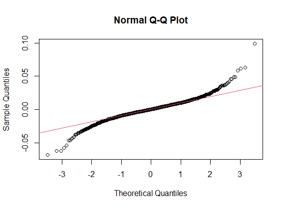

Figure 1: La droite est la distribution normale et rte la courbe en pointié

D’après la Figure 1, les queues de la distribution s’éloignent de la distribution normale (en rouge). On remarque que les deux queues de la distribution sont plus épaisses qu’une loi normale, et qu’elles sont toutes deux très prononcées, présentant une distance similaire entre la courbe et la droite de la loi normale.

## 2.2 Estimation des distributions du rendement logarithmique

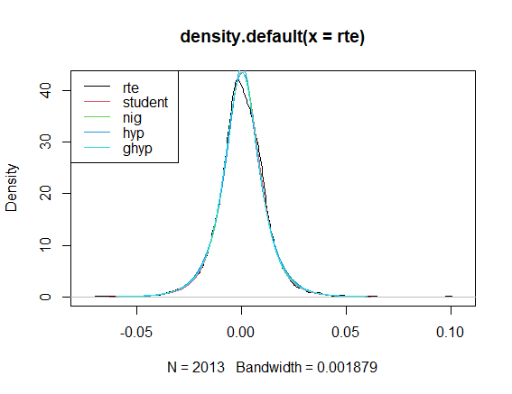

Figure 2: estimateur par noyau de la densit´e des rendements et distributions estim´ees

Parmi toutes les distributions, c’est la distribution de Student qui présente la meilleure adéquation avec celle de rendements logarithmique de Merk & Co. Par conséquent, nous allons utiliser la distribution de Student dans la suite de notre analyse

Cliquer ici pour voir en détails les résultats des estimations

## 2.3 Esitmation de modèle ARMA(1,1)-GARCH(1,1) avec une distribution de student

Nous avons exploré plusieurs modèles, à savoir le modèle APARCH ici, GJR-GARCH ici, ARCH-M ici, IGARCH ici, EGARCH ici, et ARMA(1,1)-GARCH(1,1) . Nous avons remarqué que les modèles EGARCH, GJR-GARCH et ARMA(1,1)-GARCH(1,1) modélisent correctement les rendements logarithmiques, mais le modèle ARMA(1,1)-GARCH(1,1) offre la meilleure prédiction. Par conséquent, nous avons retenu le modèle ARMA(1,1)-GARCH(1,1) comme le modèle conditionnel pour la modélisation de la Value at Risk (VaR) du rendement logarithmique de Merck & Co.

Sous l’hypothèse de la distribution de student, l’équation du modèle ARMA(1,1)-GARCH(1,1) est la suivante:

$\begin{cases} r_t = \mu + \phi_1 r_{t-1} + \theta_1 \varepsilon_{t-1} + v_t \ ( Equation \ de \ la \ moyenne)\\ vt = \sigma_t \epsilon_t \\ \sigma^2_t = \alpha_0 + \alpha_1v^2_{t-1} + \beta_1\sigma^2_{t-1} \ (Equation \ de \ la \ volatilité) \\ \epsilon_t \text{ i.i.d. Student}(\nu) \end{cases}$

avec $\mu$ la moyen du rendement logarithmique, $\phi_1$ le coefficeint Auto-regresif d’ordre 1 $\theta_1$ le coefficient de moyen-mobile d’ordre 1 $\alpha_1>0$, $\beta_1\leq0$ et $\alpha_1+\beta_1< 1$ La contrainte sur $\alpha_1+\beta_1< 1$ implique que la variance non conditionnelle de vt est finie et que sa variance conditionnelle varie dans le temps. et $\epsilon_t \text{ i.i.d. Student}(\nu)$

```
*---------------------------------*
*          GARCH Model Fit        *
*---------------------------------*

Conditional Variance Dynamics
-----------------------------------
GARCH Model : sGARCH(1,1)
Mean Model  : ARFIMA(1,0,1)
Distribution    : std

Optimal Parameters
------------------------------------
        Estimate  Std. Error   t value Pr(>|t|)
mu      0.000481    0.000159    3.0335 0.002418
ar1     0.955463    0.005819  164.1919 0.000000
ma1    -0.975082    0.001712 -569.4013 0.000000
omega   0.000012    0.000000   24.4707 0.000000
alpha1  0.117380    0.010288   11.4093 0.000000
beta1   0.807049    0.018643   43.2892 0.000000
shape   4.874963    0.480444   10.1468 0.000000

Robust Standard Errors:
        Estimate  Std. Error   t value Pr(>|t|)
mu      0.000481    0.000220    2.1828 0.029053
ar1     0.955463    0.005612  170.2547 0.000000
ma1    -0.975082    0.001680 -580.4765 0.000000
omega   0.000012    0.000001   19.4092 0.000000
alpha1  0.117380    0.013007    9.0242 0.000000
beta1   0.807049    0.022604   35.7037 0.000000
shape   4.874963    0.653504    7.4597 0.000000

LogLikelihood : 6237.475

Information Criteria
------------------------------------

Akaike       -6.1902
Bayes        -6.1707
Shibata      -6.1903
Hannan-Quinn -6.1831
```

[output cut: 41 more lines]

```
Sign Bias Test
------------------------------------
                   t-value   prob sig
Sign Bias            1.904 0.0570   *
Negative Sign Bias   1.286 0.1986
Positive Sign Bias   1.493 0.1357
Joint Effect         4.392 0.2222

Adjusted Pearson Goodness-of-Fit Test:
------------------------------------
  group statistic p-value(g-1)
1    20     19.28       0.4390
2    30     26.33       0.6078
3    40     30.06       0.8473
4    50     46.64       0.5694
```

**Tableau Robust Standard Errors**

- Contient les coefficients estimés par Maximum de Vraisemblance (MV) dans `estimate`.
- Les écarts-types estimés (robustes à l’hétéroscédasticité) des coefficients dans `Std.Error`.
- Les statistiques t associées à $H_0$ de nullité de chaque coefficient pris séparément dans `t value`.
- Enfin, la p-value correspondante dans `Pr(>| t |)`.

Les p-valeurs de “Robust Standard Errors” associées aux coefficients du modèle ARMA(1,1)-GARCH(1,1) sont toutes inférieures à 5%. Cependant, il est important de noter que le coefficient ar1 est très proches de 1, de même que le coefficient de ma1 qui est très proches de -1. De plus, les t-students associés à ces coefficients sont également élevés. Tout cela suggère un problème potentiel dans l’estimation du modèle.

**Tableau de Weighted Ljung-Box Test on Standardized Residuals**

La statistique de Ljung-Box pondérée a été appliquée aux résidus standardisés.

- l’hypothèse nulle (H0) d’absence d’autocorrélation.
- l’hypothèse alternative (H1) présence d’autocorrélation.

Les aléas ne sont pas autocorrélés car les p-valeurs du test de Ljung-Box pondéré sur les résidus standardisés sont supérieures à 0.05. Par conséquent, nous acceptons l’hypothèse nulle (H0) d’absence d’autocorrélation.Le modèle ARMA(1,1) a réussi à prendre en compte toute l’autocorrélation présente dans les rendements.

**Tableau de Weighted ARCH LM**

- Le statistique d’Engle a été appliquée aux résidus standardisés pour différents retards.
- l’hypothèse nulle $(H_0)$ de l’absence de clusters de volatilité. -l’hypothèse alternative $(H_A)$ de présence de clusters de volatilité.

Les aléas sont conditionnellement homoscédastiques car les p-valeurs des tests de Weighted ARCH LM sont supérieures à 0.05. Par conséquent, nous acceptons l’hypothèse nulle (H0) de l’absence de clusters de volatilité. ,ainsi, le modèle GARCH(1,1) a réussi à prendre en compte tous les clusters de volatilité présents dans le rendment logarithmique.

**Tableau de Nyblom stability test**

Le test de stabilité des coefficients individuels rt et jointe  
- l’hypothèse nulle $(H_0)$ stabilité des coefficients . -l’hypothèse alternative $(H_A)$ non stabilité des coefficients Si la valeur de la statistique calculée est suppérieur à valeur critique lue, on rejette l’hypothèse nulle de statbilité.

la statistique joint de Nyblom stability test est 58.9143 > 1.68, donc on rejette $(H_0)$.les coefficients ne sont pas stables.

**Tableau de Sign Biais Test**

- S’il existe un effet de levier dans nos rt, est-ce que le modèle de la variance conditionnelle choisi l’a pris en compte ?
- Le test nommé Sign Bias Test d’Engle et Ng (1993) est basé sur l’équation suivante :

  $v_t^2 = c_0 + c_1I(v_{t-1} < 0) + c_2I(v_{t-1} < 0)v_{t-1} + c_3I(v_{t-1} \geq 0)v_{t-1} + u_t$

**Adjusted Pearson Goodness of fit**

Pour évaluer si la distribution que nous avons postulée dans la spécification (distribution.model) correspond effectivement à la distribution empirique des résidus standardisés, nous avons recours à un test d’adéquation. L’hypothèse nulle est l’adéquation entre ces deux distributions. Les quatre valeurs de p supérieures à 0,05 indiquent que la loi de Student convient au rendement logarithmique de Merk et Co .

## 2.4 La prévision avec ARMA(1,1)-GARCH(1,1)

Pour valider un modèle de calcul et de prévision de la VaR, nous avons divisé l’échantillon en deux sous-échantillons : un pour l’estimation et un pour la prévision. Cette approche permet d’obtenir une série de prévision de la VaR afin de les comparer avec les rendements historiques. Ceci facilite la mise en œuvre de tests de validation. Nous allons utiliser les prévisions obtenues par fenêtre glissante. Ce processus implique d’estimer un modèle avec les T premières observations, puis de générer une prévision pour la date T + 1 afin de calculer la VaR. Ensuite, il consiste à réexaminer les modèles pour les dates allant de 2 à T + 1 inclus, suivi de la réalisation d’une prévision pour la date T + 2, et ainsi de suite

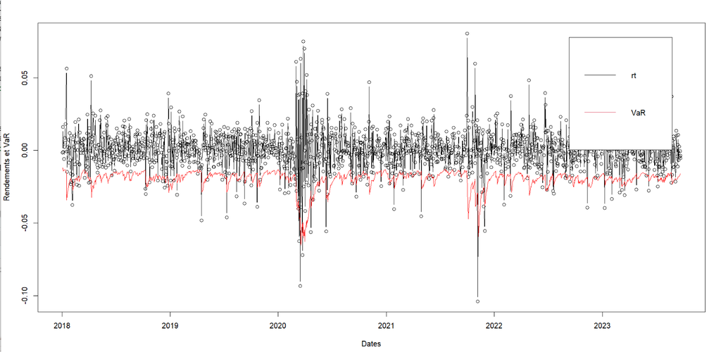

Figure 3: VaR avec la méthode de fenêtre glissante

## 2.5 Backtesting de la VaR conditionnelle

Le backtesting implique une comparaison quotidienne entre la VaR estimée et les pertes réellement observées. En principe, lorsqu’on teste une VaR à 99 %, on s’attend à ce que les rendements quotidiens du portefeuille dépassent la VaR environ une fois sur 100

Une violation de la VaR se produit lorsque les pertes réelles dépassent la VaR prédite. C’est le cas lorsque la perte observée est plus grande que la VaR attendue, symbolisée par l’inégalité $rt ≤ VaR_{t+1|t}(q)$. Pour détecter ces violations, on utilise souvent une variable binaire, la fonction Hit, où elle vaut 1 si la perte dépasse la VaR et 0 sinon.

Cette série de 1 et de 0 identifie les périodes où les pertes réelles dépassent la VaR anticipée, Si le modèle VaR est correct, le taux de violations devrait être égal à q.

On peut tester cette hypothèse en utilisant le test LR de Kupiec (1995), qui compare le taux de violations empirique avec le taux théorique. Ce test suit une distribution χ² si l’hypothèse que le taux de violation est correct est vraie.

Cependant, ce test ignore les violations potentielles de l’hypothèse d’indépendance entre les périodes. Le test de couverture conditionnelle de Christoffersen et al. (2001) corrige cela en évaluant à la fois la fréquence et l’indépendance des violations. Ce test, basé sur un rapport de vraisemblance (LR), suit une distribution χ² à 2 degrés de liberté.”

```
VaR Backtest Report
===========================================
Model:              sGARCH-std
Backtest Length:    1440
Data:

==========================================
alpha:              5%
Expected Exceed:    72
Actual VaR Exceed:  85
Actual %:           5.9%

Unconditional Coverage (Kupiec)
Null-Hypothesis:    Correct Exceedances
LR.uc Statistic:    2.341
LR.uc Critical:     3.841
LR.uc p-value:      0.126
Reject Null:        NO

Conditional Coverage (Christoffersen)
Null-Hypothesis:    Correct Exceedances and
                    Independence of Failures
LR.cc Statistic:    3.398
LR.cc Critical:     5.991
LR.cc p-value:      0.183
Reject Null:        NO
```

La valeur de la P-value du test de Kupiec est supérieure à 5%, ce qui nous conduit à ne pas rejeter l’hypothèse nulle. En conséquence, le taux de violations empiriques est égal au taux théorique.

De même, la P-value du test de Christoffersen, prenant en compte les violations de l’hypothèse d’indépendance entre les périodes, est également supérieure à 5%. Ainsi, le taux de violations empiriques est égal au taux théorique.

En conclusion, nous pouvons affirmer que la VaR est correctement estimée par le modèle paramétrique ARMA(1,1)-GARCH(1,1).

Cliquez ici pour voir backtesting de GJR-GARCH

Cliquez ici pour voir backtesting de EGARCH

## 3. Modélisation de la VaR normale, VaR modifié de Cornish-Fisher, VaR par simulation historique

## 3.1 Modélisation de la VaR normale

La Value at Risk (VaR) normale est une mesure couramment utilisée en finance pour évaluer le niveau potentiel de perte d’un actif financier sur un horizon donné avec un certain degré de confiance.

#### Notations :

- $p_t$ et $p_s$ représentent les prix d’un actif aux dates $t$ et $s$ respectivement, avec $t > s$.
- La variation entre ces deux dates, dénommée fonction de profit et perte, est définie comme $\Delta p_{s,t} = p_t - p_s$. Si $\Delta p_{s,t} > 0$, il s’agit d’un bénéfice ; sinon, c’est une perte.
- On suppose que la valeur de l’actif est stationnaire, ce qui implique que $\Delta p_{s,t}$ est une variable aléatoire dont la loi de probabilité dépend uniquement de la durée $(t - s)$ de l’intervalle $[s, t]$.

Pour une VaR normale, l’hypothèse est que $\Delta p_t$ suit une distribution normale $N(\mu(\Delta p_t), \sigma(\Delta p_t))$. La VaR peut alors être formulée comme suit :

$$P\left(\frac{\Delta p_t - \mu(\Delta
p_t)}{\sigma(\Delta p_t)} \leq \frac{\text{VaR}_q - \mu(\Delta
p_t)}{\sigma(\Delta p_t)}\right) = 1 - q$$

Ici, $\mu(\Delta p_t)$ représente l’espérance des variations de prix, $\sigma(\Delta p_t)$ la volatilité (c’est-à-dire l’écart-type) des variations de prix, et $\frac{\text{VaR}_q - \mu(\Delta p_t)}{\sigma(\Delta p_t)}$ le quantile de la distribution normale centrée réduite, noté $\Phi^{-1}(1 - q)$.

Comme $\Phi^{-1}(1 - q) = -\Phi^{-1}(q)$, on peut donc réécrire la VaR comme suit :

$$VaR_q = E(\Delta p_t) - \Phi^{-1}(q)
\sigma_{\Delta p_t}$$

Comme nous calculerons la VaR en utilisant des rendements logarithmiques, celle-ci sera exprimée en pourcentage. Pour obtenir une VaR en valeur, il suffira de multiplier la valeur de votre portefeuille par la VaR calculée en pourcentage.

## 3.2 VaR modifié de Cornish-Fisher

La Value at Risk (VaR) modifiée de Cornish-Fisher est une approche qui ajuste la VaR pour tenir compte des asymétries et des kurtoses dans la distribution des rendements. On ajuste l’équation de la VaR normale pour prendre en compte l’asymétrie et les queues épaisses de la distribution des pertes et profits.

$$MVaR_q = E(\Delta p_t) + z_{cf}(q)
\sigma_{\Delta p_t}$$

avec

$$z_{cf} = z_c + \left( \left(\frac{z_c^2
- 1}{6}\right) + \left(\frac{z_c^3 - 3z_c}{24}\right) \right) + \left(
\frac{2z_c^3 - 5z_c}{36} \right)$$

où $z_c = -\Phi^{-1}(q)$, $s$ est le skewness, et $k$ est l’excès de kurtosis. Lorsque les rendements sont normalement distribués, $s = k = 0$, et $MVaR = VaR$. Si la distribution est proche de la normale, alors $MVaR$ est plus adaptée (Jaschke, 2002). Cependant, si la distribution s’éloigne de la normale, une autre méthode doit être employée pour calculer la VaR.

## 3.3 VaR par simulation historique

La Value at Risk (VaR) par simulation historique est une méthode de calcul de la VaR qui repose sur l’analyse des variations historiques des rendements financiers d’un actif ou d’un portefeuille. On suppose que la distribution de la variable aléatoire $Δ = (X(1) − X(0) )/ X(0)$ est bien représentée par les observations Δ(t) = (X(t) − X(t − 1)) / X(t − 1), où t = −T + 1, …, −1, 0 (2).

La relation X(1) − X(0) = Δ × X(0) (3) permet d’obtenir la valeur future du risque X par :

$$X(t) = X(0) + Δ(t) \times
X(0)$$

pour t = −T + 1, …, −1, 0 (4).

Ainsi, la distribution de la variation future de la valeur est donnée par :

$$Δp(t) = \frac{X(t)(1) - X(0)}{X(0)} =
Δ(t) \times X(0)$$

pour t = −T + 1, …, −1, 0 (5).

En procédant ensuite au classement des variations de valeur futures par ordre croissant, la Value at Risk (VaR) est égale au quantile de la distribution des variations futures (en cas d’un grand nombre de valeurs) ou de manière identique au rendement correspondant au seuil de la fonction de répartition de la perte au niveau 1-q (en cas d’un nombre limité d’observations).

## 3.4 Baktesting la VaR normale,VaR modifié de Cornish-Fisher, Var par simulation historique

L’objectif du Backtesting ici est d’évaluer la performance prédictive de chaque méthode de VaR. Les résultats du Backtesting fournissent des indications sur la capacité de chaque approche à estimer correctement les risques

La VaR normale est souvent basée sur l’hypothèse d’une distribution normale des rendements. Lors du Backtesting, on compare la VaR normale estimée avec les pertes réelles sur la période spécifiée. Les résultats permettent d’évaluer la capacité de la VaR normale à anticiper les événements extrêmes et à fournir une estimation précise des risques.

La VaR modifiée de Cornish-Fisher ajuste la VaR en prenant en compte la skewness et la kurtosis des rendements. Le Backtesting implique la comparaison de cette VaR ajustée avec les pertes réelles. Ce processus permet de déterminer si l’ajustement effectué par la méthode de Cornish-Fisher améliore la précision de la VaR dans la capture des risques.

La VaR par simulation historique utilise les données passées pour simuler différentes trajectoires possibles des rendements et évaluer la distribution des pertes potentielles. Lors du Backtesting, la VaR par simulation historique est confrontée aux pertes réellement observées. Cette approche offre une perspective dynamique et réaliste, en prenant en compte la variabilité des rendements historiques.

| VaR | expected | actual | Kupiecpv | Christoffersenpv |
| --- | --- | --- | --- | --- |
| Normale | 72 | 79 | 0.40781077 | 0.5133911 |
| HS | 72 | 86 | 0.10133543 | 0.2415580 |
| CF | 72 | 89 | 0.04777513 | 0.1375133 |

Les valeurs de p des tests de Kupiecpv et du test de Christoffersenpv pour la VaR normale et la VaR HS sont supérieures à 5%. Cela indique que nous ne pouvons pas rejeter l’hypothèse nulle. En conséquence, le taux de violations empiriques est égal au taux théorique, suggérant que ces deux VaR sont correctement estimées.

Cependant, en ce qui concerne la VaR modifiée de CF, le test de Kupiecpv (p-value inférieure à 5%) suggère que la VaR n’est pas correctement estimée. En revanche, le test de Christoffersenpv (p-value supérieure à 5%) indique que la VaR est correctement estimée.

En résumé, les résultats des tests de Kupiecpv et de Christoffersenpv fournissent des indications divergentes quant à la précision de la VaR modifiée de CF. Alors que le premier suggère une estimation incorrecte, le second confirme une estimation correcte. Cette divergence souligne l’importance de considérer plusieurs tests et critères pour évaluer la performance des modèles de VaR.

## 4 Conclusion

En conclusion, nos analyses approfondies des différentes méthodes de calcul de la Value-at-Risk (VaR) pour les rendements logarithmiques de Merck & Co. ont mis en lumière des résultats significatifs. La VaR normale, bien qu’ayant un taux de violation proche du taux théorique, présente des p-values élevées, suggérant une sous-estimation du risque en raison de la distribution plus épaisse des rendements logarithmiques par rapport à la loi normale.

En somme, la VaR conditionnelle basée sur le modèle ARMA(1,1)-GARCH(1,1) émerge comme la méthode la plus fiable dans la modélisation et la prévision du risque pour les actions de Merck & Co., offrant ainsi des perspectives précieuses pour la prise de décision stratégique dans le contexte pharmaceutique et de santé.

## 5 Annexes

#### Annexe 1 :Résultats d’estimation des distributions

#### Cliquer ici pour retour sur estimations des distributions

```
Gaussian Distribution:

Parameters:
          mu        sigma
0.0003524265 0.0120961242

Call:
fit.gaussuv(data = rte)

Optimization information:
log-Likelihood:                6031.31
AIC:                           -12058.62
Fitted parameters:             mu, sigma;  (Number: 2)
Number of iterations:          0
Converged:                     TRUE

Asymmetric Student-t Distribution:

Parameters:
           nu            mu         sigma         gamma
 3.9755592480  0.0004549434  0.0122266612 -0.0001009784

Call:
fit.tuv(data = rte, silent = T)

Optimization information:
log-Likelihood:                6180.7
AIC:                           -12353.4
Fitted parameters:             lambda, mu, sigma, gamma;  (Number: 4)
Number of iterations:          119
Converged:                     TRUE

Asymmetric Normal Inverse Gaussian Distribution:

Parameters:
    alpha.bar            mu         sigma         gamma
 8.980749e-01  4.031152e-04  1.192387e-02 -5.047918e-05

Call:
fit.NIGuv(data = rte, silent = T)
```

[output cut: 26 more lines]

```

Parameters:
       lambda     alpha.bar            mu         sigma         gamma
-1.8818958550  0.2787718872  0.0004610119  0.0121121417 -0.0001104993

Call:
fit.ghypuv(data = rte, silent = T)

Optimization information:
log-Likelihood:                6180.774
AIC:                           -12351.55
Fitted parameters:             lambda, alpha.bar, mu, sigma, gamma;  (Number: 5)
Number of iterations:          502
Converged:                     FALSE
Error code:                    1
```

#### Annexe 2: La prise en compte de la saisonnalté

Nous envisageons d’intégrer les coefficients de saisonnalité au modèle ARMA(1,1)-GARCH(1,1). Cette extension vise à prendre en compte les variations saisonnières potentielles qui peuvent influencer les rendements financiers de Merck & Co. au fil du temps. L’intégration de coefficients de saisonnalité dans notre modèle permettra une modélisation plus complète, prenant en considération les facteurs temporels périodiques qui pourraient impacter les mouvements des prix des actions.

```
*---------------------------------*
*          GARCH Model Fit        *
*---------------------------------*

Conditional Variance Dynamics
-----------------------------------
GARCH Model : sGARCH(1,1)
Mean Model  : ARFIMA(1,0,1)
Distribution    : std

Optimal Parameters
------------------------------------
        Estimate  Std. Error    t value Pr(>|t|)
mu      0.000517    0.000140    3.68478 0.000229
ar1     0.955456    0.005775  165.44098 0.000000
ma1    -0.975065    0.002210 -441.14332 0.000000
mxreg1 -0.000359    0.000528   -0.68012 0.496430
mxreg2  0.000491    0.000757    0.64902 0.516324
omega   0.000012    0.000000   24.17426 0.000000
alpha1  0.119193    0.007467   15.96302 0.000000
beta1   0.804367    0.015969   50.37024 0.000000
shape   4.879096    0.459574   10.61656 0.000000

Robust Standard Errors:
        Estimate  Std. Error    t value Pr(>|t|)
mu      0.000517    0.000364    1.42309  0.15471
ar1     0.955456    0.005898  162.00892  0.00000
ma1    -0.975065    0.004692 -207.81965  0.00000
mxreg1 -0.000359    0.000572   -0.62865  0.52958
mxreg2  0.000491    0.000834    0.58897  0.55588
omega   0.000012    0.000001   18.80020  0.00000
alpha1  0.119193    0.014210    8.38798  0.00000
beta1   0.804367    0.022936   35.06982  0.00000
shape   4.879096    0.605806    8.05390  0.00000
```

Les coefficients associ´ees `a ces nouvelles variables sont nomm´es mxreg1 pour l’effet lundi et mxreg2 pour l’effet janvier. Les coefficients de saisonnalité mxreg1 mxreg2 ne sont pas significatif car les p-value associé sont supérieur à 5%

#### Annexe 3: Le modèle ARCH-M

Le rendement d’un titre peut dépendre souvent de sa volatilité, on considère un modèle GARCH-M tel qu’un GARCH(1,1)-M :

$$r_t = \mu + \phi_1 r_{t-1} + \theta_1
\varepsilon_{t-1} + c\sigma^2_t + v_t, \quad v_t = \sigma_t\epsilon_t$$

$$\sigma^2_t = \alpha_0 +
\alpha_1v^2_{t-1} + \beta_1\sigma^2_{t-1}$$

où $\mu$ et $c$ sont des constantes. $c$ est appelé le paramètre de prime de risque. Si $c > 0$, alors le rendement est positivement relié à sa volatilité.

```
*---------------------------------*
*          GARCH Model Fit        *
*---------------------------------*

Conditional Variance Dynamics
-----------------------------------
GARCH Model : sGARCH(1,1)
Mean Model  : ARFIMA(1,0,1)
Distribution    : std

Optimal Parameters
------------------------------------
        Estimate  Std. Error     t value Pr(>|t|)
mu      0.000352    0.001332    0.264614  0.79131
ar1     0.955261    0.005843  163.485976  0.00000
ma1    -0.974933    0.001290 -755.811730  0.00000
archm   0.011611    0.121336    0.095696  0.92376
omega   0.000011    0.000000   24.108648  0.00000
alpha1  0.116906    0.009598   12.179690  0.00000
beta1   0.808536    0.017646   45.820193  0.00000
shape   4.869742    0.472376   10.309048  0.00000

Robust Standard Errors:
        Estimate  Std. Error     t value Pr(>|t|)
mu      0.000352    0.002038    0.172913  0.86272
ar1     0.955261    0.005552  172.049381  0.00000
ma1    -0.974933    0.001569 -621.351093  0.00000
archm   0.011611    0.186562    0.062239  0.95037
omega   0.000011    0.000001   18.531877  0.00000
alpha1  0.116906    0.010822   10.802335  0.00000
beta1   0.808536    0.019698   41.046693  0.00000
shape   4.869742    0.619428    7.861671  0.00000

LogLikelihood : 6237.485

Information Criteria
------------------------------------

Akaike       -6.1893
Bayes        -6.1670
```

[output cut: 45 more lines]

```
------------------------------------
                   t-value    prob sig
Sign Bias            1.776 0.07585   *
Negative Sign Bias   1.220 0.22250
Positive Sign Bias   1.422 0.15512
Joint Effect         3.907 0.27165


Adjusted Pearson Goodness-of-Fit Test:
------------------------------------
  group statistic p-value(g-1)
1    20     22.14       0.2773
2    30     31.66       0.3348
3    40     31.97       0.7803
4    50     44.30       0.6637
```

Le coefficient ARCH-M n’est pas significatif, donc ce n’est pas un bon modèle pour le rendement de Merk & Co.

Cliquez ici pour revenir à l’estimation du modèle ARMA(1,1)-GARCH(1,1)

#### Annexe 4: Le modèle IGARCH

Le modèle de processus GARCH intégré (IGARCH) est défini par les équations suivantes :

$$v_t = \sigma_t \epsilon_t$$

$$\sigma^2_t = \alpha_0 + \beta_1
\sigma^2_{t-1} + (1 - \beta_1) v^2_{t-1}$$

Où $\{\epsilon_t\}$ sont définis comme précédemment, et $1 > \beta_1 > 0$. En théorie, les phénomènes IGARCH sont causés par des changements occasionnels dans le niveau de la volatilité. Quand $\alpha_1 + \beta_1 = 1$, des substitutions répétées dans l’équation (12) donnent :

$$\sigma^2_h(l) = \sigma^2_h(1) + (l - 1)
\alpha_0, \quad l > 1$$

- L’effet de $\sigma^2_h(1)$ sur les volatilités futures est persistant, et les prévisions de la volatilité forment une ligne droite de pente $\alpha_0$.
- Si $\alpha_0 = 0$ dans un modèle IGARCH(1,1), alors quels que soient les horizons de prévisions retenus, ils sont tous égaux à $\sigma^2_h(1)$.

```
*---------------------------------*
*          GARCH Model Fit        *
*---------------------------------*

Conditional Variance Dynamics
-----------------------------------
GARCH Model : iGARCH(1,1)
Mean Model  : ARFIMA(1,0,1)
Distribution    : std

Optimal Parameters
------------------------------------
        Estimate  Std. Error   t value Pr(>|t|)
mu      0.000461    0.000130    3.5425 0.000396
ar1     0.955366    0.005943  160.7530 0.000000
ma1    -0.975302    0.001657 -588.5266 0.000000
omega   0.000006    0.000003    2.2645 0.023541
alpha1  0.150719    0.035058    4.2992 0.000017
beta1   0.849281          NA        NA       NA
shape   3.979698    0.359449   11.0717 0.000000

Robust Standard Errors:
        Estimate  Std. Error   t value Pr(>|t|)
mu      0.000461    0.000161    2.8689 0.004119
ar1     0.955366    0.005697  167.6824 0.000000
ma1    -0.975302    0.001863 -523.3720 0.000000
omega   0.000006    0.000004    1.3375 0.181045
alpha1  0.150719    0.058356    2.5827 0.009802
beta1   0.849281          NA        NA       NA
shape   3.979698    0.475388    8.3715 0.000000

LogLikelihood : 6229.691

Information Criteria
------------------------------------

Akaike       -6.1835
Bayes        -6.1668
Shibata      -6.1835
Hannan-Quinn -6.1774
```

[output cut: 41 more lines]

```
------------------------------------
                   t-value    prob sig
Sign Bias           1.6743 0.09423   *
Negative Sign Bias  0.7697 0.44159
Positive Sign Bias  1.5547 0.12017
Joint Effect        3.4984 0.32097


Adjusted Pearson Goodness-of-Fit Test:
------------------------------------
  group statistic p-value(g-1)
1    20     26.83       0.1086
2    30     35.93       0.1757
3    40     43.25       0.2945
4    50     53.44       0.3075
```

Tout les coefficients sont significatifs sauf le cofficient associé à oméga, mais ARMA(1,1)-GARCH(1,1) est préférable puisque tous les coefficients sont sgnificatifs

Cliquez ici pour revenir à l’estimation du modèle ARMA(1,1)-GARCH(1,1)

#### Annexe 5: Le Modèle EGARCH

#### Formulation du Modèle

Le modèle EGARCH est formulé comme suit :

$$v_t = \sigma_t \epsilon_t, \\
\ln\sigma_t^2 = \alpha_0 + \frac{1 + \sum_{i=1}^{s-1}\beta_i L^i}{1 -
\sum_{i=1}^{m}\alpha_i L^i} g(\epsilon_{t-1})$$

où $L$ est l’opérateur retard, $g(\epsilon_t) = \theta \epsilon_t + \gamma \left(|\epsilon_t| - E(|\epsilon_t|)\right)$ avec $\theta$ et $\gamma$ des constantes réelles. $E(\epsilon_t)$ et $|\epsilon_t| - E(|\epsilon_t|)$ sont des séquences i.i.d. avec des distributions continues et de moyenne nulle.

Ce modèle permet une forme d’asymétrie dépendant du signe de l’innovation et de l’amplitude de ce choc.

Dans le package `rugarch`, le modèle EGARCH(m,s) peut être réécrit comme suit :

$$v_t = \sigma_t \epsilon_t, \\
\ln\sigma_t^2 = \alpha_0 + \sum_{i=1}^{s}\alpha_i|\epsilon_{t-i}| +
\sum_{i=1}^{m}\gamma_i\epsilon_{t-i}\sigma_{t-i} +
\sum_{j=1}^{m}\beta_j\ln(\sigma_{t}^2 - j)$$

L’effet de levier est représenté par les $\gamma_i$ qui doivent être significatifs et négatifs. Une bonne nouvelle ($\epsilon_{t-i} > 0$) a un impact sur la volatilité en logarithme égal à $\alpha_i(1 + \gamma_i)|\epsilon_{t-1}|$, alors qu’une mauvaise nouvelle a un impact égal à $\alpha_i(1 - \gamma_i)|\epsilon_{t-1}|$.

#### Propriétés du Modèle

1. La moyenne non conditionnelle de $\ln(\sigma_t^2) = \alpha_0$.
2. Il utilise le logarithme de la variance conditionnelle pour relaxer la contrainte de positivité des coefficients.

L’asymétrie de $g(\epsilon_t)$ peut se réécrire comme suit :

$$g(\epsilon_t) =
\begin{cases}
(\theta + \gamma)\epsilon_t - \gamma E(|\epsilon_t|) & \text{si }
\epsilon_t \geq 0 \text{ (bonne nouvelle)} \\
(\theta - \gamma)\epsilon_t - \gamma E(|\epsilon_t|) & \text{sinon
(mauvaise nouvelle)}
\end{cases}$$

Pour $\epsilon_t \sim N$, $E(|\epsilon_t|) = \frac{\sqrt{2}}{\sqrt{\pi}} \approx 0.7979$. Pour $\epsilon_t \sim t(v)$, $E(|\epsilon_t|) = \frac{2\sqrt{v-2}\Gamma\left(\frac{v+1}{2}\right)}{(v-1)\Gamma\left(\frac{v}{2}\right)\sqrt{\pi}}$.

Dans le package `rugarch`, l’effet du signe (bonne ou mauvaise nouvelle) est nommé `alpha1`, et on a un effet de levier si $\alpha_1 < 0$, et l’effet taille se nomme comme ici $\gamma$. Plus il est grand, plus l’effet de levier est grand, ce qui se traduira par sa positivité.

```
*---------------------------------*
*          GARCH Model Fit        *
*---------------------------------*

Conditional Variance Dynamics
-----------------------------------
GARCH Model : eGARCH(1,1)
Mean Model  : ARFIMA(1,0,1)
Distribution    : std

Optimal Parameters
------------------------------------
        Estimate  Std. Error     t value Pr(>|t|)
mu      0.000362    0.000041      8.9267  0.0e+00
ar1     0.963228    0.004808    200.3269  0.0e+00
ma1    -0.979660    0.000067 -14557.5361  0.0e+00
omega  -0.618199    0.076814     -8.0480  0.0e+00
alpha1 -0.087650    0.019973     -4.3883  1.1e-05
beta1   0.931146    0.008527    109.2056  0.0e+00
gamma1  0.211530    0.030458      6.9449  0.0e+00
shape   5.133295    0.532604      9.6381  0.0e+00

Robust Standard Errors:
        Estimate  Std. Error     t value Pr(>|t|)
mu      0.000362    0.000046      7.8315 0.000000
ar1     0.963228    0.004841    198.9925 0.000000
ma1    -0.979660    0.000070 -14028.8501 0.000000
omega  -0.618199    0.043297    -14.2780 0.000000
alpha1 -0.087650    0.024870     -3.5243 0.000425
beta1   0.931146    0.004899    190.0658 0.000000
gamma1  0.211530    0.032821      6.4449 0.000000
shape   5.133295    0.624415      8.2210 0.000000

LogLikelihood : 6252.582

Information Criteria
------------------------------------

Akaike       -6.2043
Bayes        -6.1820
```

[output cut: 45 more lines]

```
------------------------------------
                   t-value    prob sig
Sign Bias           1.7535 0.07968   *
Negative Sign Bias  0.7269 0.46736
Positive Sign Bias  0.9746 0.32989
Joint Effect        3.0982 0.37673


Adjusted Pearson Goodness-of-Fit Test:
------------------------------------
  group statistic p-value(g-1)
1    20     24.74       0.1691
2    30     25.05       0.6758
3    40     35.07       0.6499
4    50     56.13       0.2254
```

Tous les coefficients sont statistiquement significatifs, et de plus l’effet de levier `alpha1` est significatifs et négatifs. Nous pouvons conclure que le modèle eGARCH(1,1) est un bon modèle pour modéliser les caractéristiques du rendments logarithmique de Merk & Co.

Cliquez ici pour revenir à l’estimation du modèle ARMA(1,1)-GARCH(1,1)

#### Annexe 6 : Modèle GJR-GARCH (Glosten Jagannathan Runkle-GARCH (1993))

#### Formulation du Modèle

Le modèle GJR-GARCH(1,1) est formulé comme suit :

$$r_t = \mu + v_t \\
v_t = \sigma_t \epsilon_t \\
\sigma_t^2 = \alpha_0 + \sum_{i=1}^{m} (\alpha_i v_{t-1}^2 + \gamma_i
I_{t-i<0}v_{t-1}^2) + \sum_{j=1}^{s} \beta_j \sigma_{t-1}^2$$

où $\epsilon_t$ sont des bruits blancs et où $I_{t-i} = 1$ si $v_{t-i} < 0$ et 0 sinon.

Dans ce modèle, des contraintes sur les paramètres sont imposées pour garantir la positivité de la variance conditionnelle : $\alpha_0 > 0$, $\alpha_i \geq 0$ pour $i = 1, \ldots, m$, et $\beta_j \geq 0$ pour $j = 1, \ldots, s$.

#### Principe du Modèle

La dynamique de la variance conditionnelle admet un changement de régime qui dépend du signe de l’innovation passée. Une nouvelle variable explicative est introduite comme le produit d’une indicatrice de l’événement en question et de la variable initiale.

Lorsqu’il y a un choc positif en $t-i$, les effets totaux sont $\alpha_i v_{t-1}^2$, mais lorsqu’il y a un choc négatif, les effets totaux valent $(\alpha_i + \gamma_i) v_{t-1}^2$.

La présence d’un effet de levier implique que les $\gamma$ soient $> 0$.

*Annexe : Modèle GJR-GARCH(1,1) {#gjr}*

Le modèle GJR-GARCH(1,1) est formulé comme suit :

$$r_t = \mu + v_t \\
v_t = \sigma_t \epsilon_t \\
\sigma_t^2 =
\begin{cases}
\alpha_0 + (\alpha_1 + \gamma) v_{t-1}^2 + \beta_1 \sigma_{t-1}^2 &
\text{si } \epsilon_{t-1} \leq 0 \\
\alpha_0 + \alpha_1 v_{t-1}^2 + \beta_1 \sigma_{t-1}^2 &
\text{sinon}
\end{cases}$$

Remarque : Le modèle TGARCH de Zakoian (1994) est similaire au GJR, sauf qu’il modélise l’écart-type conditionnel au lieu de la variance conditionnelle.

```
*---------------------------------*
*          GARCH Model Fit        *
*---------------------------------*

Conditional Variance Dynamics
-----------------------------------
GARCH Model : gjrGARCH(1,1)
Mean Model  : ARFIMA(1,0,1)
Distribution    : std

Optimal Parameters
------------------------------------
        Estimate  Std. Error    t value Pr(>|t|)
mu      0.000421    0.000044     9.6316 0.000000
ar1     0.963336    0.004842   198.9708 0.000000
ma1    -0.980739    0.000134 -7337.2243 0.000000
omega   0.000012    0.000000    39.6839 0.000000
alpha1  0.036320    0.010704     3.3930 0.000691
beta1   0.812144    0.015765    51.5171 0.000000
gamma1  0.149480    0.035503     4.2104 0.000025
shape   5.072189    0.505122    10.0415 0.000000

Robust Standard Errors:
        Estimate  Std. Error    t value Pr(>|t|)
mu      0.000421    0.000031    13.6302 0.000000
ar1     0.963336    0.004671   206.2219 0.000000
ma1    -0.980739    0.000128 -7666.0214 0.000000
omega   0.000012    0.000000    30.0946 0.000000
alpha1  0.036320    0.014706     2.4697 0.013523
beta1   0.812144    0.017115    47.4528 0.000000
gamma1  0.149480    0.047219     3.1657 0.001547
shape   5.072189    0.646498     7.8456 0.000000

LogLikelihood : 6246.447

Information Criteria
------------------------------------

Akaike       -6.1982
Bayes        -6.1759
```

[output cut: 45 more lines]

```
------------------------------------
                   t-value   prob sig
Sign Bias           1.5523 0.1207
Negative Sign Bias  0.4867 0.6265
Positive Sign Bias  0.8538 0.3933
Joint Effect        2.5118 0.4732


Adjusted Pearson Goodness-of-Fit Test:
------------------------------------
  group statistic p-value(g-1)
1    20     19.86       0.4033
2    30     32.95       0.2799
3    40     39.08       0.4662
4    50     57.72       0.1842
```

$\gamma$ est significatif et positif donc le moèle prend en compte l’effet de levier.

Cliquez ici pour revenir à l’estimation du modèle ARMA(1,1)-GARCH(1,1)

#### Annexe 7 : Le modèle APARCH

#### Formulation du Modèle

Un processus $v_t$ satisfait une représentation AP ARCH(m, s) si :

$$r_t = \mu + v_t \\
v_t = \sigma_t \epsilon_t \\
\sigma_t^\delta = \alpha_0 + \sum_{i=1}^{s} \alpha_i \left(|v_{t-i}| -
\gamma_i v_{t-i}\right)^\delta + \sum_{i=1}^{m} \beta_i
\sigma_t^{\delta-i}$$

La positivité de $\sigma_t$ est assurée par les conditions : - $\alpha_0 > 0$, - $\alpha_i \geq 0$, - $-1 < \gamma_i < 1$, pour $i = 1, \ldots, s$, - $\beta_i \geq 0$, pour $i = 1, \ldots, m$, - $\delta > 0$. En fait, pour avoir une signification, $\delta$ doit être égal à 1 (écart-type conditionnel) ou 2 (variance conditionnelle).

La stationnarité du second ordre d’un processus APARCH nécessite :

$$\sum_{i=1}^{s} \alpha_i E \left[ \left(|v_{t-i}| - \gamma_i
v_{t-i}\right)^\delta \right] + \sum_{i=1}^{m} \beta_i
\sigma_t^{\delta-i} < 1$$

#### APARCH(1,1)

Le modèle APARCH(1,1) est formulé comme suit :

$$r_t = \mu + v_t \\
v_t = \sigma_t \epsilon_t \\
\sigma_t^\delta = \alpha_0 + \alpha_1 \left(|v_{t-1}| - \gamma_1
v_{t-1}\right)^\delta + \beta_1 \sigma_t^{\delta-1}$$

On remarque que (18) correspond à un processus : - ARCH(1) quand $\delta = 2$, $\gamma_1 = \beta_1 = 0$ - GARCH(1,1) quand $\delta = 2$, $\gamma_1 = 0$ - GJR-GARCH(1,1) quand $\delta = 2$

```
*---------------------------------*
*          GARCH Model Fit        *
*---------------------------------*

Conditional Variance Dynamics
-----------------------------------
GARCH Model : apARCH(1,1)
Mean Model  : ARFIMA(1,0,1)
Distribution    : std

Optimal Parameters
------------------------------------
        Estimate  Std. Error    t value Pr(>|t|)
mu      0.000406    0.000367    1.10816  0.26779
ar1     0.951459    0.004993  190.55024  0.00000
ma1    -0.973176    0.003788 -256.93290  0.00000
omega   0.000000    0.000001    0.15947  0.87330
alpha1  0.034724    0.027800    1.24907  0.21164
beta1   0.814959    0.014254   57.17515  0.00000
gamma1  0.578757    0.383795    1.50798  0.13156
delta   3.039353    0.045588   66.67014  0.00000
shape   4.941503    0.472818   10.45118  0.00000

Robust Standard Errors:
        Estimate  Std. Error   t value Pr(>|t|)
mu      0.000406     0.02504  0.016226 0.987054
ar1     0.951459     0.54098  1.758760 0.078618
ma1    -0.973176     0.24810 -3.922581 0.000088
omega   0.000000     0.00005  0.002175 0.998264
alpha1  0.034724     2.56711  0.013527 0.989208
beta1   0.814959     2.39864  0.339759 0.734038
gamma1  0.578757    35.12686  0.016476 0.986854
delta   3.039353     4.95044  0.613956 0.539244
shape   4.941503    14.20471  0.347878 0.727932

LogLikelihood : 6237.202

Information Criteria
------------------------------------

```

[output cut: 48 more lines]

```
------------------------------------
                   t-value   prob sig
Sign Bias           1.2442 0.2136
Negative Sign Bias  0.5429 0.5872
Positive Sign Bias  0.3537 0.7236
Joint Effect        1.7052 0.6358


Adjusted Pearson Goodness-of-Fit Test:
------------------------------------
  group statistic p-value(g-1)
1    20     27.37      0.09638
2    30     36.70      0.15400
3    40     47.15      0.17370
4    50     48.57      0.49028
```

Tous les coefficient ne sont significatifs sauf le coefficient de ma1. donc ce n’est pas le bon modèle.

Tout le dleta est égale à 3 nous allons le fixer à 2, pour voir la significacité des autres coefficients.

```
*---------------------------------*
*          GARCH Model Fit        *
*---------------------------------*

Conditional Variance Dynamics
-----------------------------------
GARCH Model : apARCH(1,1)
Mean Model  : ARFIMA(1,0,1)
Distribution    : nig

Optimal Parameters
------------------------------------
        Estimate  Std. Error     t value Pr(>|t|)
mu      0.000437    0.000005  8.2135e+01 0.000000
ar1     0.957774    0.005368  1.7842e+02 0.000000
ma1    -0.976783    0.000076 -1.2851e+04 0.000000
omega   0.000013    0.000000  4.7963e+01 0.000000
alpha1  0.091522    0.008220  1.1134e+01 0.000000
beta1   0.802520    0.015541  5.1638e+01 0.000000
gamma1  0.421116    0.095841  4.3939e+00 0.000011
delta   2.000000          NA          NA       NA
skew    0.015811    0.041445  3.8149e-01 0.702841
shape   1.297078    0.195700  6.6279e+00 0.000000

Robust Standard Errors:
        Estimate  Std. Error     t value Pr(>|t|)
mu      0.000437    0.000009  5.0462e+01 0.000000
ar1     0.957774    0.005240  1.8279e+02 0.000000
ma1    -0.976783    0.000077 -1.2702e+04 0.000000
omega   0.000013    0.000000  4.4127e+01 0.000000
alpha1  0.091522    0.010246  8.9321e+00 0.000000
beta1   0.802520    0.017126  4.6861e+01 0.000000
gamma1  0.421116    0.109510  3.8454e+00 0.000120
delta   2.000000          NA          NA       NA
skew    0.015811    0.047908  3.3002e-01 0.741384
shape   1.297078    0.262402  4.9431e+00 0.000001

LogLikelihood : 6238.94

Information Criteria
```

[output cut: 53 more lines]

```
Negative Sign Bias  0.5476 0.5840
Positive Sign Bias  0.7843 0.4329
Joint Effect        2.6659 0.4460


Adjusted Pearson Goodness-of-Fit Test:
------------------------------------
  group statistic p-value(g-1)
1    20     26.39      0.11958
2    30     35.75      0.18102
3    40     49.45      0.12182
4    50     65.12      0.06138


Elapsed time : 4.736422
```

Cliquez ici pour revenir à l’estimation du modèle ARMA(1,1)-GARCH(1,1)

#### Annexe 8: Le résultat de backtesting avec le modèle eGARCH

```
VaR Backtest Report
===========================================
Model:              eGARCH-std
Backtest Length:    1440
Data:

==========================================
alpha:              5%
Expected Exceed:    72
Actual VaR Exceed:  89
Actual %:           6.2%

Unconditional Coverage (Kupiec)
Null-Hypothesis:    Correct Exceedances
LR.uc Statistic:    3.943
LR.uc Critical:     3.841
LR.uc p-value:      0.047
Reject Null:        YES

Conditional Coverage (Christoffersen)
Null-Hypothesis:    Correct Exceedances and
                    Independence of Failures
LR.cc Statistic:    3.997
LR.cc Critical:     5.991
LR.cc p-value:      0.136
Reject Null:        NO
```

On constate que le test de Kupiec rejette l’hypothèse nulle. Par conséquent, nous n’allons pas utiliser le modèle eGARCH.

Cliquez ici pour revenir à Backtesting de la VaR conditionnelle

#### Annexe 9: Le résultat de backtesting avec le modèle GJR-GARCH(1,1)

```
VaR Backtest Report
===========================================
Model:              gjrGARCH-std
Backtest Length:    1440
Data:

==========================================
alpha:              5%
Expected Exceed:    72
Actual VaR Exceed:  88
Actual %:           6.1%

Unconditional Coverage (Kupiec)
Null-Hypothesis:    Correct Exceedances
LR.uc Statistic:    3.506
LR.uc Critical:     3.841
LR.uc p-value:      0.061
Reject Null:        NO

Conditional Coverage (Christoffersen)
Null-Hypothesis:    Correct Exceedances and
                    Independence of Failures
LR.cc Statistic:    3.537
LR.cc Critical:     5.991
LR.cc p-value:      0.171
Reject Null:        NO
```

Cliquez ici pour revenir à Backtesting de la VaR conditionnelle